# ANOVA 2

Mar 03 2026

## Chapters for ANOVA/ANCOVA

**R book**

**Chapter 11:** Analysis of Variance and

**Chapter 12:** Analysis of Covariance

**ISLR**

Not covered per se, but you can check for relevant materials

**Chapter 3, Section 3.3.1**: Qualitative Predictors

## Last time: two parametrizations

```r
mod1 <- lm(yield~soil, data=yields, contrasts = "contr.sum")
round(summary(mod1)$coef,4)
```

```
##             Estimate Std. Error t value Pr(>|t|)
## (Intercept)     11.9     0.6241 19.0673   0.0000
## soil(clay)      -0.4     0.8826 -0.4532   0.6540
## soil(loam)       2.4     0.8826  2.7192   0.0113
```

```r
mod2 <- lm(yield~soil, data=yields, contrasts = "contr.treatment")
round(summary(mod2)$coef,4)
```

```
##             Estimate Std. Error t value Pr(>|t|)
## (Intercept)     11.5     1.0810 10.6385   0.0000
## soil(loam)       2.8     1.5287  1.8316   0.0781
## soil(sand)      -1.6     1.5287 -1.0466   0.3046
```

## anova(mod1) and anova(mod2)

```
## Analysis of Variance Table
##
## Response: yield
##           Df Sum Sq Mean Sq F value  Pr(>F)
## soil       2   99.2  49.600  4.2447 0.02495 *
## Residuals 27  315.5  11.685
## ---
## Signif. codes:  0 '***' 0.001 '**' 0.01 '*' 0.05 '.' 0.1 ' ' 1
```

```
## Analysis of Variance Table
##
## Response: yield
##           Df Sum Sq Mean Sq F value  Pr(>F)
## soil       2   99.2  49.600  4.2447 0.02495 *
## Residuals 27  315.5  11.685
## ---
## Signif. codes:  0 '***' 0.001 '**' 0.01 '*' 0.05 '.' 0.1 ' ' 1
```

## Residual analysis

We should also for ANOVA-models check the assumptions by residual analysis

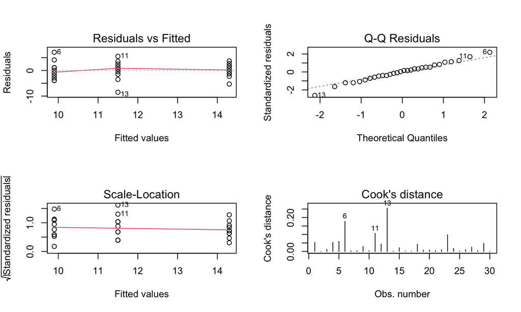

## ANOVA with several factors

- Each with two or more levels
- Assume two factors: A with \(i=1,2,...a\) levels, and B with \(j=1,2,...,b\) levels
- If all levels of A are tested with all levels of B we have a complete crossed design
- Assume there are \(k=1,2,...,r\) replicates of all \(ab\) level combinations so
- So, the total number of observations is \(n = a\cdot b\cdot r\)

## Illustration of two-factor case

https://solve.shinyapps.io/Factorialdemo/

## The Model

Model: \[y_{ijk} = \mu_{ij} + \epsilon_{ijk} = \mu + \alpha_i + \beta_j + (\alpha\beta)_{ij} + \epsilon_{ijk}\]

where \(\epsilon_{ijk} \sim N(0,\sigma^2)\) and \((\alpha\beta)_{ij}\) is the effect due to any interaction between the *i*-th level of \(A\) and the *j*-th level of \(B\).

Parametrization (restrictions)

- Sum-to-zero: \(\sum_i {\alpha}_i =0\), \(\sum_j {\beta}_j=0\), \(\sum_i (\alpha\beta)_{ij}=0\) and \(\sum_j (\alpha\beta)_{ij}=0\).
- Reference levels: \(\alpha_1 = 0\), \(\beta_1 = 0\), \((\alpha\beta)_{1j}=0\) for all \(j\) and \((\alpha\beta)_{i1}=0\) for all \(i\).

## Example: Animal diets - “growth data” from R book

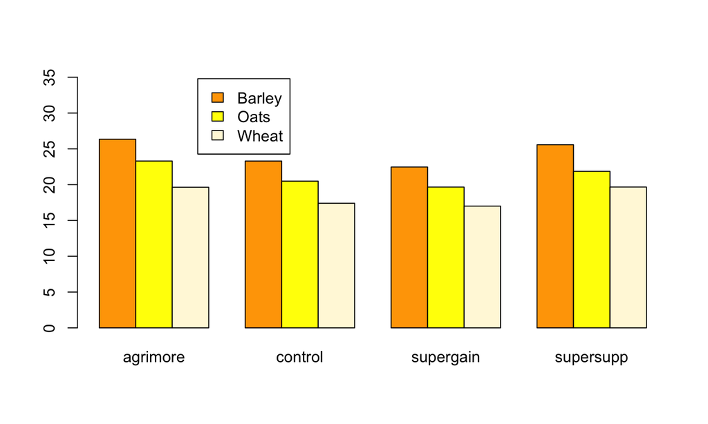

## R structure of the data

```
##    supplement  diet     gain
## 1   supergain wheat 17.37125
## 2   supergain wheat 16.81489
## 3   supergain wheat 18.08184
## 4   supergain wheat 15.78175
## 5     control wheat 17.70656
## 6     control wheat 18.22717
## 7     control wheat 16.08650
## 8     control wheat 17.60184
## 9   supersupp wheat 20.78861
## 10  supersupp wheat 20.00858
## 11  supersupp wheat 19.30287
## 12  supersupp wheat 18.57330
## 13   agrimore wheat 19.54688
## 14   agrimore wheat 17.96440
## 15   agrimore wheat 21.43738
## 16   agrimore wheat 19.60763
```

## R analysis

Let’s see how to use both parametrizations here:

```r
#mixlm
mod1<- mixlm::lm(gain ~ diet + supplement + diet:supplement,
           data=weights, contrasts = "contr.treatment")
#base R
options(contrasts = c("contr.treatment", "contr.poly"))
mod1 <- stats::lm(gain ~ diet + supplement + diet:supplement,
           data=weights)
#mixlm
mod2 <- mixlm::lm(gain ~ diet + supplement + diet:supplement,
           data=weights, contrasts = "contr.sum")
#base R
options(contrasts = c("contr.sum", "contr.poly"))
mod2 <- stats::lm(gain ~ diet + supplement + diet:supplement,
           data=weights)
```

## Main effects plot of `Diet`

“Main effect plots” of group means with 95% CI’s

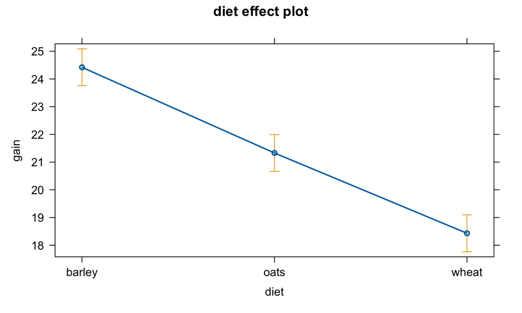

```r
library(effects)
plot(Effect(focal.predictors = c("diet"), mod = mod2))
```

## Main effects plot of `Supplement`

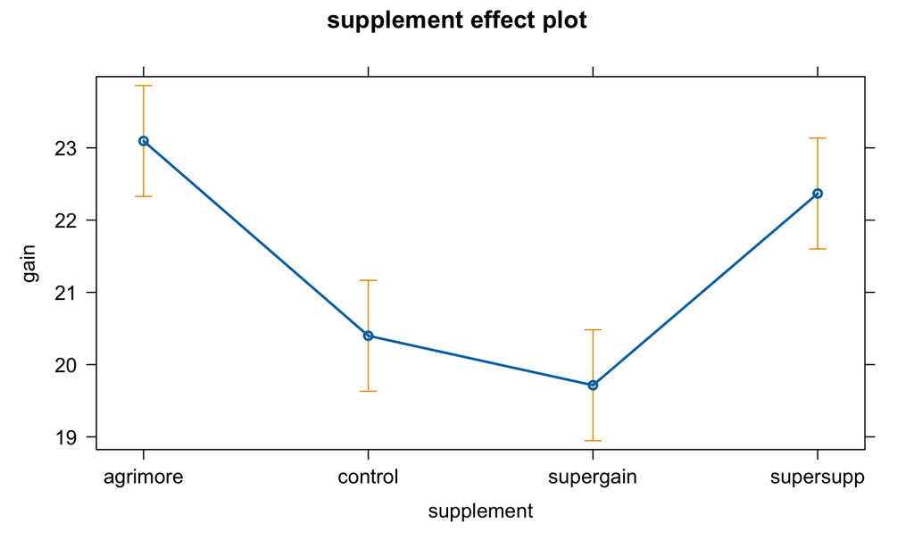

```r
plot(Effect(c("supplement"), mod2))
```

## Interaction plots

Means of diet:supplement combinations.

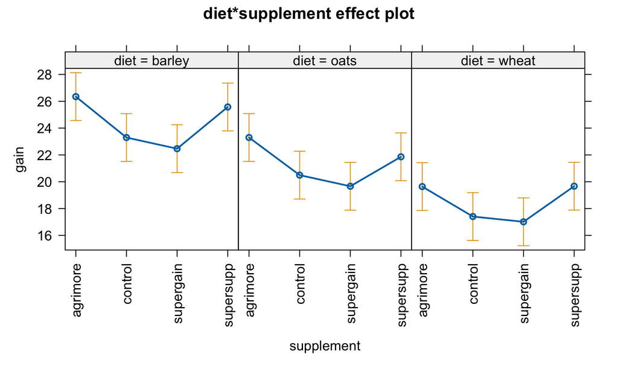

```r
plot(allEffects(mod2,confidence.level=.99),layout=c(3,1),
     rotx=90,alternating=FALSE)
```

## Model parameter estimation

Still likelihood maximization/ SSE minimization in the regression formulation of 2-way ANOVA with interactions to get \(\widehat{\beta_0},\widehat{\beta_1},...,\widehat{\beta_p}\) which can similarly to how we did it last time translated into \(\widehat{\mu},\widehat{\alpha}_i, \widehat{\beta}_j,\widehat{(\alpha\beta)}_{ij}\). For balanced data the least squares estimators for the model parameters are (sum-to-zero):

\(\widehat{\mu} = \bar{y}_{...}\)

\(\widehat{\alpha}_i = \bar{y}_{i..}-\bar{y}_{...}\)

\(\widehat{\beta}_j = \bar{y}_{.j.}-\bar{y}_{...}\)

\(\widehat{(\alpha\beta)}_{ij} = \bar{y}_{ij.} - \bar{y}_{i..} - \bar{y}_{.j.} + \bar{y}_{...}\)

Interpretation: effects are **deviations** from the overall mean \(\mu\).

## Model parameter estimation

Now take level 1 of A and B as reference

\(\widehat{\mu}^{(ref)} = \bar{y}_{11.}\)

\(\widehat{\alpha}_i^{(ref)} = \bar{y}_{i1.} - \bar{y}_{11.},\quad i = 2,\ldots,a\)

\(\widehat{\beta}_j^{(ref)} = \bar{y}_{1j.} - \bar{y}_{11.},\quad j = 2,\ldots,b\)

\(\widehat{(\alpha\beta)}_{ij}^{(ref)} = \bar{y}_{ij.} - \bar{y}_{i1.} - \bar{y}_{1j.} + \bar{y}_{11.}, \quad i=2,\ldots,a,\; j=2,\ldots,b\)

Interpretation: effects are **differences** from the reference.

As usual, the noise variance estimate is:

\(\widehat{\sigma}^2 = MSE\)

## Summary with sum to zero:

Sum to zero parametrization - deviations from the grand mean:

```
##                                    Estimate Std. Error  t value Pr(>|t|)
## (Intercept)                         21.3939     0.1893 113.0450   0.0000
## diet(barley)                         3.0277     0.2676  11.3125   0.0000
## diet(oats)                          -0.0651     0.2676  -0.2433   0.8092
## supplement(agrimore)                 1.7014     0.3278   5.1904   0.0000
## supplement(control)                 -0.9953     0.3278  -3.0364   0.0044
## supplement(supergain)               -1.6801     0.3278  -5.1254   0.0000
## diet(barley):supplement(agrimore)    0.2255     0.4636   0.4864   0.6297
## diet(oats):supplement(agrimore)      0.2682     0.4636   0.5785   0.5665
## diet(barley):supplement(control)    -0.1297     0.4636  -0.2797   0.7813
## diet(oats):supplement(control)       0.1602     0.4636   0.3455   0.7317
## diet(barley):supplement(supergain)  -0.2754     0.4636  -0.5942   0.5561
## diet(oats):supplement(supergain)     0.0143     0.4636   0.0308   0.9756
```

## Summary with reference:

Reference diet: **barley**, supplement: **agrimore**

```
##                                   Estimate Std. Error t value Pr(>|t|)
## (Intercept)                        26.3485     0.6556 40.1907   0.0000
## diet(oats)                         -3.0501     0.9271 -3.2898   0.0022
## diet(wheat)                        -6.7094     0.9271 -7.2367   0.0000
## supplement(control)                -3.0518     0.9271 -3.2917   0.0022
## supplement(supergain)              -3.8824     0.9271 -4.1875   0.0002
## supplement(supersupp)              -0.7732     0.9271 -0.8339   0.4098
## diet(oats):supplement(control)      0.2471     1.3112  0.1885   0.8516
## diet(wheat):supplement(control)     0.8183     1.3112  0.6241   0.5365
## diet(oats):supplement(supergain)    0.2470     1.3112  0.1884   0.8517
## diet(wheat):supplement(supergain)   1.2557     1.3112  0.9577   0.3446
## diet(oats):supplement(supersupp)   -0.6650     1.3112 -0.5072   0.6151
## diet(wheat):supplement(supersupp)   0.8024     1.3112  0.6120   0.5444
```

## We want to test hypotheses

Interaction effects? \[H_0:(\alpha\beta)_{11} = (\alpha\beta)_{12} = \cdots = (\alpha\beta)_{ab} = 0\]

Main effect of A? \[H_0:\alpha_1 = \alpha_2=\cdots=\alpha_a = 0\]

Main effect of B? \[H_0:\beta_1 = \beta_2 = \cdots = \beta_b = 0\]

## Splitting of sums of squares

The Total Sums of Squares measures total variability: \[ SST = \sum_i \sum_j \sum_k (y_{ijk} - \bar{y}_{...})^2 \]

Can be split into: \[ SST = SSA + SSB + SSAB + SSE \]

Degrees of freedom follow correspondingly as \[ (n - 1) = [(a - 1)] + [(b - 1)] + [(a - 1)(b - 1)] + [n - ab]. \] This corresponds to a linear regression formulation with \(SSR = SSA + SSB + SSAB\) and \(p = ab - 1\)

## F-tests

Interaction: Reject \(H_0\) if \[ F = \frac{MS{AB}}{MSE} = \frac{SS{AB}/[(a-1)(b-1)]}{SSE/[n - ab]} \] is larger than \(F_{\alpha,\,(a-1)(b-1),\,n-ab}\) or p-value \(< \alpha\).

Main effect A: Reject \(H_0\) if \[ F = \frac{MSA}{MSE} > F_{\alpha,\,(a-1),\,n-ab} \]

Main effect B: Reject \(H_0\) if \[ F = \frac{MSB}{MSE} > F_{\alpha,\,(b-1),\,n-ab} \]

## The ANOVA-table for the growth data

```r
anova(mod2)
```

```
## Analysis of Variance Table
##
## Response: gain
##                 Df  Sum Sq Mean Sq F value    Pr(>F)
## diet             2 287.171 143.586 83.5201 2.999e-14 ***
## supplement       3  91.881  30.627 17.8150 2.952e-07 ***
## diet:supplement  6   3.406   0.568  0.3302    0.9166
## Residuals       36  61.890   1.719
## ---
## Signif. codes:  0 '***' 0.001 '**' 0.01 '*' 0.05 '.' 0.1 ' ' 1
```

Conclusions?

## A reduced model

```r
mod3 <- lm(gain ~ diet + supplement, data=weights, contrasts = "contr.sum")
anova(mod3)
```

```
## Analysis of Variance Table
##
## Response: gain
##            Df  Sum Sq Mean Sq F value    Pr(>F)
## diet        2 287.171 143.586  92.358 4.199e-16 ***
## supplement  3  91.881  30.627  19.700 3.980e-08 ***
## Residuals  42  65.296   1.555
## ---
## Signif. codes:  0 '***' 0.001 '**' 0.01 '*' 0.05 '.' 0.1 ' ' 1
```

Note: The complete crossed design gives “orthogonal effects”. The SS’s are independent, and, apart from SSE, they do not change when effects are removed/added to the model.

## Tukey tests supplement

```r
ptests <- mixlm::simple.glht(mod3, "supplement", corr = c("Tukey"),
                             level = 0.95)
print(round(ptests$res,4))
```

```
##                       Lower  Center   Upper Std.Err t value  P(>t)
## agrimore-control     1.3351  2.6967  4.0583   0.509  5.2977 0.0000
## agrimore-supergain   2.0198  3.3815  4.7431   0.509  6.6429 0.0000
## agrimore-supersupp  -0.6343  0.7274  2.0890   0.509  1.4289 0.4889
## control-supergain   -0.6769  0.6848  2.0464   0.509  1.3452 0.5400
## control-supersupp   -3.3310 -1.9693 -0.6077   0.509 -3.8688 0.0020
## supergain-supersupp -4.0157 -2.6541 -1.2925   0.509 -5.2141 0.0000
```

## Tukey tests diet

```r
ptests2 <- mixlm::simple.glht(mod3, "diet", corr = c("Tukey"),
                             level = 0.95)
print(round(ptests2$res,4))
```

```
##               Lower Center  Upper Std.Err t value P(>t)
## barley-oats  2.0218 3.0928 4.1638  0.4408  7.0159     0
## barley-wheat 4.9193 5.9903 7.0613  0.4408 13.5886     0
## oats-wheat   1.8265 2.8975 3.9685  0.4408  6.5727     0
```

## Compact letter display

A compact letter display (cld) of groups of effects

```r
cld(ptests)
```

```
## Tukey's HSD
## Alpha: 0.05
##
##               Mean G1 G2
## agrimore  23.09531     B
## supersupp 22.36796     B
## control   20.39861  A
## supergain 19.71385  A
```

## Analysis of covariance - ANCOVA

The dataset `birth` in the BIAS.data package holds records of 189 birth weights from Massachusetts, USA, and some additional variables. Three of the variables are,

| Var | Description |
| --- | --- |
| `LWT` | Weight of mother. |
| `SMK` | `YES` if mother smokes and `NO` otherwise. |
| `BWT` | Birth weight (RESPONSE). |

The main question is: Does mother’s smoking affect birth weight and does it depend on the mother weight?

We have both a categorical and a continuous predictor for the response variable.

## The data

```
##   LWT SMK  BWT
## 1 120 YES  709
## 2 130  NO 1021
## 3 187 YES 1135
## 4 105  NO 1330
## 5  85  NO 1474
## 6 150  NO 1588
## 7  97  NO 1588
```

## Scatterplot with separate linear models for smokers and non-smokers

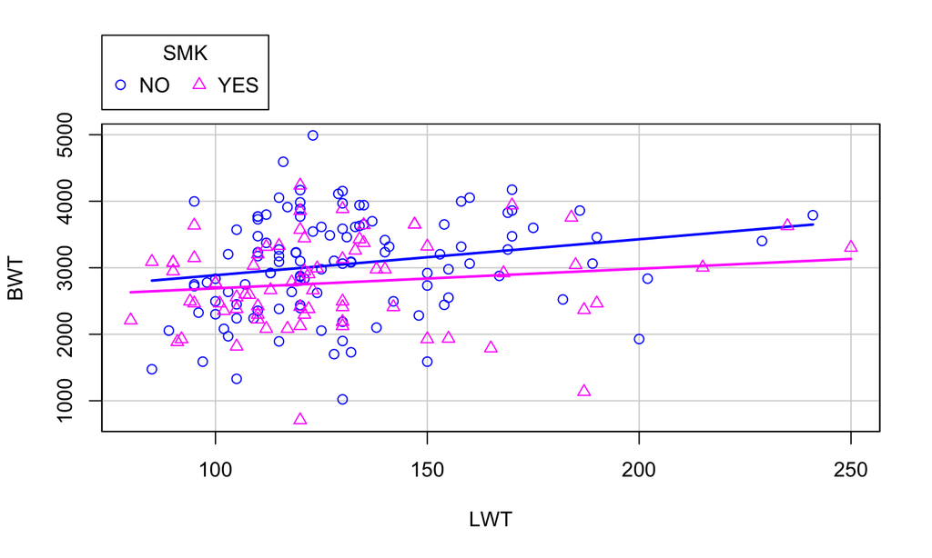

## ANCOVA as regression with indicator variable

Let \(y = BWT\) and \(x_1 = LWT\) and define \[ x_{2i} = \left\{ \begin{array}[cc] \ 0 & \mbox{if non smoker}\\ 1 & \mbox{if smoker} \end{array} \right. \]

Assume the model \[ y_i = \beta_0 + \beta_1 x_{1i} + \beta_2 x_{2i} + \epsilon_i \] where \(\epsilon_i \sim N(0, \sigma^2)\).

## Fitting the model in R

```r
birth4 <- lm(BWT ~ LWT + SMK, data=birth, contrasts = "contr.treatment")
summary(birth4)
```

```
##
## Call:
## lm(formula = BWT ~ LWT + SMK, data = birth, contrasts = "contr.treatment")
##
## Residuals:
##      Min       1Q   Median       3Q      Max
## -2030.16  -447.00    27.74   514.20  1968.51
##
## Coefficients:
##             Estimate Std. Error t value Pr(>|t|)
## (Intercept) 2500.174    230.833  10.831   <2e-16 ***
## LWT            4.238      1.690   2.508   0.0130 *
## SMK(YES)    -270.013    105.590  -2.557   0.0114 *
## ---
## Signif. codes:  0 '***' 0.001 '**' 0.01 '*' 0.05 '.' 0.1 ' ' 1
##
## s: 707.8 on 186 degrees of freedom
## Multiple R-squared: 0.06731,
## Adjusted R-squared: 0.05728
## F-statistic: 6.711 on 2 and 186 DF,  p-value: 0.001533
```

## The estimated model(s)

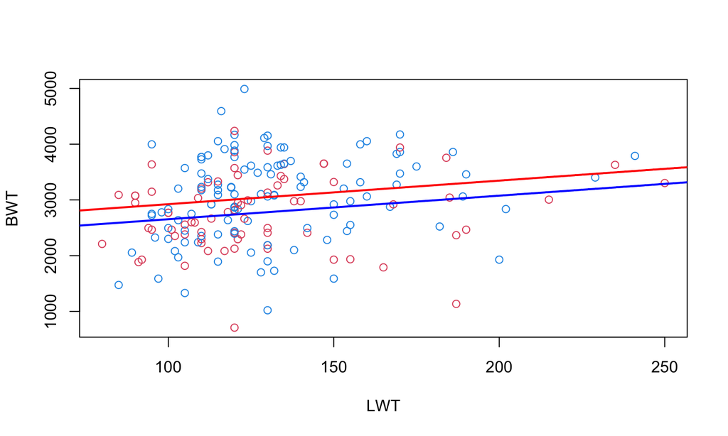

## The model with interaction term

Assume that we expand the model with an interaction term between LWT and SMK \[ y_i = \beta_0 + \beta_1 x_{1i} + \beta_2 x_{2i} + \beta_3 x_{1i}\cdot x_{2i} + \epsilon_i \] with \(\epsilon_i \sim N(0, \sigma^2)\).

Lets see how the model is for different values of \(x_{2i}\)

## Fitted model in R

```
##
## Call:
## lm(formula = BWT ~ LWT * SMK, data = birth, contrasts = "contr.treatment")
##
## Residuals:
##      Min       1Q   Median       3Q      Max
## -2040.25  -456.20    29.07   531.72  1977.72
##
## Coefficients:
##              Estimate Std. Error t value Pr(>|t|)
## (Intercept)  2347.507    312.717   7.507 2.48e-12 ***
## LWT             5.405      2.335   2.315   0.0217 *
## SMK(YES)       47.867    451.163   0.106   0.9156
## LWT:SMK(YES)   -2.456      3.388  -0.725   0.4695
## ---
## Signif. codes:  0 '***' 0.001 '**' 0.01 '*' 0.05 '.' 0.1 ' ' 1
##
## s: 708.7 on 185 degrees of freedom
## Multiple R-squared: 0.06995,
## Adjusted R-squared: 0.05487
## F-statistic: 4.638 on 3 and 185 DF,  p-value: 0.003756
```

## The estimated model(s)

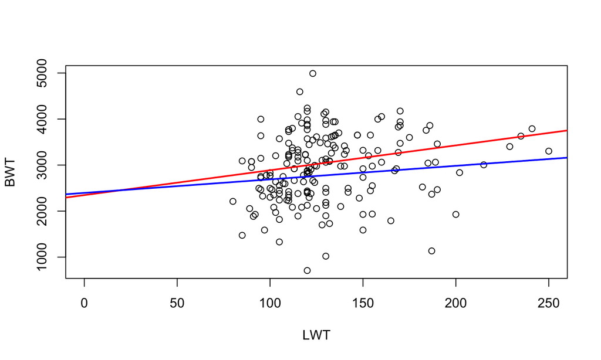

## Model summaries, tests, diagnostics

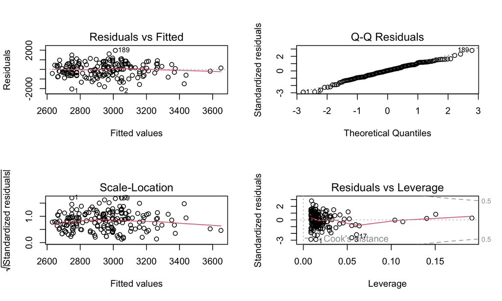

## Model summaries, tests, diagnostics

You should be able to check:

- Are model assumptions met?
- Are there significant effects of LWT and/or SMK?
- How is the model fit in terms of \(R^2\)? Critizise the model!